# CACCS: Secuencia de taller de RStudio – Parte 4

Rashid C.J. Marcano Rivera

27 de feb.º de 2025

**Análisis de redes**

Este taller está basado en elementos y ejemplos de la presentación *Introduction to `statnet` (and `igraph`) for Social Network Analysis* de Patrick Kaminski (Doctorando de Sociología y Computación IU-Bloomington) y Ann McCrannie (Instituto de Ciencias de Redes de IU), las [viñeta de `igraph`](https://r.igraph.org/articles/igraph_ES.html) y [la viñeta de `statnet`](https://statnet.org/workshop-intro-sna-tools/), así como datos de mi disertación doctoral para análisis descriptivo e inferencial, y datos de un artículo que estoy en proceso de concluir, para visualización.

Las metas de este último taller de la secuencia de talleres son:

- Introducir varios conceptos básicos del análisis de redes (con una comprensión intuitiva y recursos para leer más).
- Mostrar cómo importar, gestionar y realizar análisis básicos de redes en R.
- Hablaremos principalmente desde la tradición del **análisis de redes sociales** (SNA), pero también haremos referencia a algunos términos y herramientas comunes en la **ciencia de redes**.

*Si aún no has instalado R, está [aquí](http://cran.us.r-project.org/). Acto seguido, [baja RStudio](https://posit.co/download/rstudio-desktop/). Puedes también ir a la nube [en Posit Cloud](https://posit.cloud/).*

# 1 Hacia otro mundo

Durante las tres semanas anteriores examinamos cómo se podía trabajar en R para varios fines estadísticos y de visualización. Esto incluía el uso de herramientas censales, de manejo y manipulación de datos, así como técnicas de modelaje inferencial. Este cuarto taller es bastante distinto a los pasados dos, y a la vez, manejará el uso de técnicas descriptivas, inferenciales y de visualización, aplicados en específico a redes, todo en uno.

El análisis de redes sociales es una forma de conceptualizar, describir y modelar la sociedad como conjuntos de personas o grupos interconectados mediante relaciones específicas, ya sean estas tan tangibles como las redes de intercambio o tan intangibles como las percepciones mutuas. Los analistas de redes creen que la forma en que vive un individuo depende en gran parte de cómo está conectado a la red más amplia de relaciones sociales. Enfocarse en las redes nos ayuda a entender, por ejemplo, las actividades de las élites económicas, cómo las personas consiguen empleo, cómo los jurados alcanzan un consenso, cómo los países organizan su comercio, el fenómeno del “mundo pequeño” y la estructura de Internet.

## 1.1 Teoría de grafos

Al representar cada persona, usuario, concepto o entidad de interés como un punto, que llamaremos **nodo** o **vértice** (*node* o *vertex* en inglés), y cada conexión como una línea que llamaremos **arista** o **enlaces** (*edges* o *links* en inglés), podemos empezar a visualizar quién se conecta a quién y cómo interactúan en esa red. Un grafo (*graph*) es una estructura matemática que permite representar problemas cotidianos de manera gráfica. En ello se puede representar un tipo de relación, o múltiples. La teoría de grafos, igual que la estadística o ciencias de cómputos, es una rama de las matemáticas, y se fundamenta en ellas.

Formalmente un grafo $G=(V,E)$ es una pareja ordenada en la que $V$ es un conjunto no vacío de vértices y $E$ es un conjunto de aristas, donde $E$ consta de pares no ordenados de vértices, tales como $\{x,y\}\in E$, y entonces se dice que $x$ e $y$ son adyacentes. La arista no dirigida se representa en un grafo mediante un segmento de recta que une a dichos vértices y si fuere dirigida se le llama dígrafo denotado $D=(V,E)$ con flecha de $x$ a $y$. Ahí el par $(x,y)$ es un par ordenado y la arista dirigida se denota como $(x,y)\in E$. Para entrar a mayor profundidad en la notación y conceptos de teoría de grafos y sus algoritmos recomiendo el capítulo enlazado aquí en [arXiv](https://arxiv.org/abs/cond-mat/0602129).

El grafo social o sociograma es entonces una representación de una red social sustentada en la teoría de grafos. Hay varios tipos (simple, múltiple, hipergrafos, etc.) Las aristas pueden ser adyacentes si convergieren en el mismo vértice, paralelas si los vértices iniciales y finales fueren el mismo o cíclicas si parten del vértice para ir al mismo punto. Finalmente, se le llama camino al conjunto de vértices que están interconectados por aristas.

Los paquetes que usaremos en este taller son los siguientes:

```r
#install.packages(c("network", "sna", "igraph", "tidygraph", "ggraph", "intergraph", "remotes"))
```

# 2 Redes con R: igraph, statnet, network y tidy

Se pueden crear en igraph gráficos básicos de varias maneras, primero trabajaremos con `make_graph()`.

```r
library(igraph)
make_graph( c(1,2, 2,3, 3,4), directed=FALSE)
```

```
## IGRAPH 5f2c616 U--- 4 3 --
## + edges from 5f2c616:
## [1] 1--2 2--3 3--4
```

Esto nos indica que creó un grafo no dirigido (`--` es no dirigido, `--+` o `+--` es dirigido). En adición, se puede indicar una red con instrucciones como el `:`, refiriendo un nodo a un conjunto de nodos: `Ross -- Chandler:Joey:Rachel:Phoebe:Monica` debiera crear el conector de todos estos amigos.

```r
g <- make_graph(~ 1 - 2, 2 - 3)
g
```

```
## IGRAPH 898656d UN-- 3 2 --
## + attr: name (v/c)
## + edges from 898656d (vertex names):
## [1] 1--2 2--3
```

```r
g1 <- make_graph(~ A - B, B - C:D:E)
g1
```

```
## IGRAPH a07ed02 UN-- 5 4 --
## + attr: name (v/c)
## + edges from a07ed02 (vertex names):
## [1] A--B B--C B--D B--E
```

```r
g2 <- make_graph(~ A --+ B, B +-- C, A --+ D:E, B --+ A)
g2
```

```
## IGRAPH e095668 DN-- 5 5 --
## + attr: name (v/c)
## + edges from e095668 (vertex names):
## [1] A->B A->D A->E B->A C->B
```

```r
#quiero una red entre Ross, Chandler, Joey, Rachel., Phoebe y Mónica
g3 <- make_graph(~ Ross --+ Chandler:Joey:Rachel:Phoebe:Monica, Chandler --+ Ross:Joey:Rachel:Phoebe:Monica, Joey --+ Ross:Chandler:Rachel:Phoebe:Monica, Rachel --+ Ross:Chandler:Joey:Phoebe:Monica, Phoebe --+ Ross:Chandler:Joey:Rachel:Monica, Monica --+ Ross:Chandler:Joey:Rachel:Phoebe)
g3
```

```
## IGRAPH 176821a DN-- 6 30 --
## + attr: name (v/c)
## + edges from 176821a (vertex names):
##  [1] Ross    ->Chandler Ross    ->Joey     Ross    ->Rachel   Ross    ->Phoebe
##  [5] Ross    ->Monica   Chandler->Ross     Chandler->Joey     Chandler->Rachel
##  [9] Chandler->Phoebe   Chandler->Monica   Joey    ->Ross     Joey    ->Chandler
## [13] Joey    ->Rachel   Joey    ->Phoebe   Joey    ->Monica   Rachel  ->Ross
## [17] Rachel  ->Chandler Rachel  ->Joey     Rachel  ->Phoebe   Rachel  ->Monica
## [21] Phoebe  ->Ross     Phoebe  ->Chandler Phoebe  ->Joey     Phoebe  ->Rachel
## [25] Phoebe  ->Monica   Monica  ->Ross     Monica  ->Chandler Monica  ->Joey
## [29] Monica  ->Rachel   Monica  ->Phoebe
```

Noten que cada grafo creado tiene su nombre en objeto, y que igraph al crearlo resume lo que hay en el objeto:

- La primera línea dice la clase del objeto `IGRAPH`. A este se le asigna un identificador, y se le indica si es dirigido o no (`U` o `D`).
- Adicionalmente otras letras acompañan simbólicamente si aplica.
  - `N` es si los nodos tienen nombres,
  - `W` si tiene pesos (ninguno aquí lo tiene pero luego lo trabajaremos) o
  - `B` si es un bigrafo o bipartito.
- Luego, se indica el número de nodos y aristas, y finalmente se indica la presencia de atributos con formato `nombredeatributo(ñ/ç)`, donde
  - `ñ` informará si es un atributo de nodo, arista o del grafo y
  - `ç` informa si es
    - `n`umérico,
    - `c`aracter,
    - e`x`tendido o
    - `l`ógico.
  - Finalmente en `+edges:` se indica la lista de aristas, quizás cortándose si se extendiera mucho en grafos grandes.

R permite la visualización básica de estas redes, como podremos ver, siguiendo la misma lógica inicial de programación en R básico:

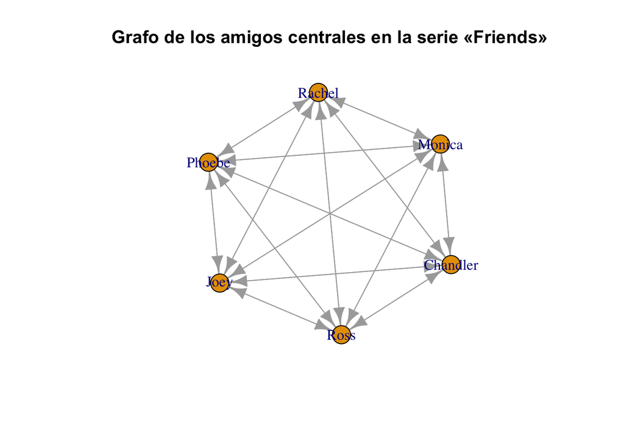

```r
plot(g3,main="Grafo de los amigos centrales en la serie «Friends»")
```

Otras funciones de `igraph` para importar o crear grafos, o viceversa, llevar un grafo a un objeto de tipo normal para `R` son usados dependiendo la estructura o arquitectura de los datos:

| objeto | objeto a `igraph` | `igraph` a objeto |
| --- | --- | --- |
| matriz de adyacencia | `graph_from_adjacency_matrix` | `as_adjacency_matrix` |
| lista de aristas | `graph_from_edgelist` | `as_edgelist` |
| `data.frame`s (marco de datos) | `graph_from_data_frame` | `as_data_frame` |

## 2.1 Importando datos de ejemplo 1

```r
#setwd("~/dirección/a/carpeta/donde/trabajan/el/Taller 4")
getwd() #ver dónde está la carpeta
```

```
## [1] "/Users/rashid/Documents/Documents - MacBook Pro de Rashid/Universidad de Puerto Rico/Servicio/Secuencia-de-Talleres-RStudio-FCS-UPRRP-Feb-2025/Taller 4"
```

```r
list.files() #ver qué hay en la carpeta
```

```
##  [1] "classroom-adjacency.csv"  "classroom-edges.csv"
##  [3] "classroom-nodes.csv"      "edgelist_2007.csv"
##  [5] "grafo_sin_aislados.RData" "GrafoRedesEcu.png"
##  [7] "introToSNAinR.Rdata"      "Nodes_2007.csv"
##  [9] "Taller-R-4_files"         "Taller-R-4.html"
## [11] "Taller-R-4.Rmd"
```

Aquí hay los siguientes objetos:

- `classroom-adjacency.csv` con la matriz de adyacencia.
- `classroom-edges.csv` con la lista de aristas que incluye un atributo (los atributos los conocen normalmente como variables o covariado y describen de alguna manera una relación/enlace/arista o un sujeto/nodo/vértice). En este caso el atributo es `liking`, de tipo numérico en escala de 1 al 5 indica cuánto a *ego* le agrada *alter*, es decir, el emisor y receptor de la relación.
- `classroom-nodes.csv` con atributos nodales: `female`, una variable binaria clasificada como lógica, `TRUE` si es niña, `FALSE` si es niño; `isei08_m` y `isei08_f`, variables numéricas que indican el estatus socioeconómico respectivo del padre y mqdre de *ego*.

Hay otros datos que examinaremos en su momento, incluidos en la carpeta como `introToSNAinR.Rdata` y los datos de redes creadas por este servidor.

```r
relations <- read.csv("classroom-adjacency.csv",header=T,row.names=1,stringsAsFactors=FALSE)
relations[1:10,1:10] #ver sección del subgrafo con notación de corchete para matrices
```

```
##      X1003 X1006 X1009 X1012 X1015 X1018 X1021 X1024 X1027 X1030
## 1003     0     0     0     0     0     1     0     0     0     0
## 1006     0     0     1     0     0     0     0     0     0     0
## 1009     0     1     0     0     0     0     0     0     0     0
## 1012     0     0     0     0     1     0     1     0     0     0
## 1015     0     0     0     1     0     0     1     0     0     0
## 1018     0     0     0     0     0     0     0     0     0     0
## 1021     0     1     1     1     0     0     0     0     0     0
## 1024     0     0     0     0     0     0     0     0     0     0
## 1027     0     1     1     0     0     0     0     0     0     0
## 1030     0     0     1     0     0     0     0     0     0     0
```

Igualaremos los nombres de columnas con filas en este caso (son los mismos sujetos tras revisar)

```r
colnames(relations) <- rownames(relations)
```

También importaremos una lista de aristas, que vemos cuenta también con una columna de atributos de aristas.

```r
edgelist<-read.csv("classroom-edges.csv",header=T,stringsAsFactors = F)
head(edgelist)
```

```
##   from   to liking
## 1 1003 1018      3
## 2 1003 1051      3
## 3 1003 1072      4
## 4 1006 1009      5
## 5 1006 1042      1
## 6 1006 1057      4
```

Si hiciéramos con `igraph` el grafo saldría así:

```r
relations <- as.matrix(relations) # convertimos a formato matriz (no es necesario estrictamente, pero se está tornando así)
graph_from_adjacency_matrix(relations, mode="directed")
```

```
## IGRAPH 778a69f DN-- 26 88 --
## + attr: name (v/c)
## + edges from 778a69f (vertex names):
##  [1] 1003->1018 1003->1051 1003->1072 1006->1009 1006->1042 1006->1057
##  [7] 1006->1078 1009->1006 1009->1057 1009->1078 1012->1015 1012->1021
## [13] 1012->1075 1015->1012 1015->1021 1015->1078 1018->1042 1018->1048
## [19] 1018->1051 1018->1060 1018->1072 1021->1006 1021->1009 1021->1012
## [25] 1021->1057 1021->1078 1027->1006 1027->1009 1027->1048 1027->1051
## [31] 1027->1057 1027->1078 1030->1009 1030->1078 1033->1051 1036->1006
## [37] 1036->1033 1036->1042 1039->1018 1039->1042 1042->1006 1042->1018
## [43] 1042->1039 1042->1051 1045->1018 1045->1042 1048->1018 1048->1042
## + ... omitted several edges
```

```r
edgelist_matrix <- as.matrix(edgelist)
head(edgelist_matrix)
```

```
##      from   to liking
## [1,] 1003 1018      3
## [2,] 1003 1051      3
## [3,] 1003 1072      4
## [4,] 1006 1009      5
## [5,] 1006 1042      1
## [6,] 1006 1057      4
```

Si tratáramos de importar la matriz anterior como un grafo, no funcionaría, pues la función `graph_from_edgelist` espera una matriz de dos columnas, no de tres. Por ello, se debe hacer una selección de las dos columnas que se desean importar, y luego se le puede añadir un atributo a las aristas.

```r
# 1. Crear el grafo a partir de las dos columnas
g <- graph_from_edgelist(as.matrix(edgelist[, c("from", "to")]),
                         directed = TRUE)

# 2. Agregar la columna 'liking' como atributo de las aristas
E(g)$liking <- edgelist$liking
g
```

```
## IGRAPH 44a0dce D--- 1078 88 --
## + attr: liking (e/n)
## + edges from 44a0dce:
##  [1] 1003->1018 1003->1051 1003->1072 1006->1009 1006->1042 1006->1057
##  [7] 1006->1078 1009->1006 1009->1057 1009->1078 1012->1015 1012->1021
## [13] 1012->1075 1015->1012 1015->1021 1015->1078 1018->1042 1018->1048
## [19] 1018->1051 1018->1060 1018->1072 1021->1006 1021->1009 1021->1012
## [25] 1021->1057 1021->1078 1027->1006 1027->1009 1027->1048 1027->1051
## [31] 1027->1057 1027->1078 1030->1009 1030->1078 1033->1051 1036->1006
## [37] 1036->1033 1036->1042 1039->1018 1039->1042 1042->1006 1042->1018
## [43] 1042->1039 1042->1051 1045->1018 1045->1042 1048->1018 1048->1042
## + ... omitted several edges
```

```r
classroom_kids <- read.csv("classroom-nodes.csv", header=TRUE, colClasses=c(name = "character"))
head(classroom_kids)
```

```
##   name female isei08_m isei08_f
## 1 1003  FALSE       NA    25.71
## 2 1006   TRUE    14.64    33.76
## 3 1009   TRUE    28.48    37.22
## 4 1012   TRUE    26.64    25.23
## 5 1015   TRUE    21.24       NA
## 6 1018  FALSE    23.47    24.45
```

```r
classroom_play <- read.csv("classroom-edges.csv", header=TRUE, colClasses = c(from="character", to="character"))
head(classroom_play)
```

```
##   from   to liking
## 1 1003 1018      3
## 2 1003 1051      3
## 3 1003 1072      4
## 4 1006 1009      5
## 5 1006 1042      1
## 6 1006 1057      4
```

```r
classroom <- graph_from_data_frame(classroom_play, vertices=classroom_kids,
                                   directed=TRUE)
classroom
```

```
## IGRAPH 1a9435b DN-- 26 88 --
## + attr: name (v/c), female (v/l), isei08_m (v/n), isei08_f (v/n),
## | liking (e/n)
## + edges from 1a9435b (vertex names):
##  [1] 1003->1018 1003->1051 1003->1072 1006->1009 1006->1042 1006->1057
##  [7] 1006->1078 1009->1006 1009->1057 1009->1078 1012->1015 1012->1021
## [13] 1012->1075 1015->1012 1015->1021 1015->1078 1018->1042 1018->1048
## [19] 1018->1051 1018->1060 1018->1072 1021->1006 1021->1009 1021->1012
## [25] 1021->1057 1021->1078 1027->1006 1027->1009 1027->1048 1027->1051
## [31] 1027->1057 1027->1078 1030->1009 1030->1078 1033->1051 1036->1006
## [37] 1036->1033 1036->1042 1039->1018 1039->1042 1042->1006 1042->1018
## + ... omitted several edges
```

## 2.2 Importando datos de ejemplo 2

```r
library(tidyverse)
```

```
## ✖ lubridate::%--%()      masks igraph::%--%()
```

```r
# Importar la lista de aristas de AR2007.xlsx
nodes_2007 <- read.csv("Nodes_2007.csv", header = TRUE, stringsAsFactors = FALSE)
edgelist_2007 <- read.csv("edgelist_2007.csv", header = TRUE, stringsAsFactors = FALSE)
nodes_2007 <- distinct(nodes_2007, ID, .keep_all = TRUE)
```

Cargar dos archivos con datos de nodos y aristas, y crear un grafo con ellos.

Para tener una idea de cómo se ven estos datos, podríamos ver las primeras o últimas seis filas de los mismos:

```r
head(nodes_2007)
```

```
##   ID                          CompanyPerson  Revenue Year   Country
## 1  1                   ypf sociedad anonima 11163296 2007 Argentina
## 2  2                 telecom argentina s.a.  3710566 2007 Argentina
## 3  3               cablevision holding s.a.       50 2007 Argentina
## 4  4 petrobras energia participaciones s.a.       50 2007 Argentina
## 5  5                       pampa energia sa  1231821 2007 Argentina
## 6  6                  nortel inversora s.a.  3710566 2007 Argentina
##       CondensedSector
## 1 Nonfinancial sector
## 2 Nonfinancial sector
## 3 Nonfinancial sector
## 4 Nonfinancial sector
## 5 Nonfinancial sector
## 6 Nonfinancial sector
```

```r
head(edgelist_2007)
```

```
##   Source Target Weight
## 1      5    126  11.46
## 2      7    327   7.40
## 3      8    133   7.81
## 4     10     16  93.60
## 5    138    143 100.00
## 6    140    389   0.94
```

```r
g_2007 <- graph_from_data_frame(d = edgelist_2007,
                                vertices = nodes_2007,
                                directed = TRUE)
g_2007
```

```
## IGRAPH 265c1cb DN-- 1540 3547 --
## + attr: name (v/c), CompanyPerson (v/c), Revenue (v/n), Year (v/n),
## | Country (v/c), CondensedSector (v/c), Weight (e/n)
## + edges from 265c1cb (vertex names):
##  [1] 5  ->126 7  ->327 8  ->133 10 ->16  138->143 140->389 141->155 141->248
##  [9] 141->319 142->146 142->200 142->277 144->276 152->151 154->228 154->234
## [17] 154->291 169->315 170->142 170->146 170->200 170->277 170->286 170->392
## [25] 177->223 177->233 210->138 210->145 210->154 210->164 210->189 210->203
## [33] 210->209 210->281 218->284 255->268 263->229 263->369 277->311 306->308
## [41] 306->388 321->344 321->357 379->216 379->395 401->357 404->255 406->190
## [49] 457->129 488->185 502->175 576->342 708->254 711->783 715->732 717->755
## + ... omitted several edges
```

En este caso he tomado un grafo que incluye una serie de atributos como nombre de accionista o entidad, ingresos, año identificado (en este caso todos son 2007), país de persona o entidad (este listado de entidades cubre a México, Argentina, Brasil y Chile), el sector económico al que pertenecen las entidades (bancos, sector financiero general, sector no financiero, individuos o familias, sector público, etc.). Finalmente, como atributo de arista está la acción sostenida por un actor en otro de 0 al 100 como `Weight`.

Podríamos visualizar este grafo:

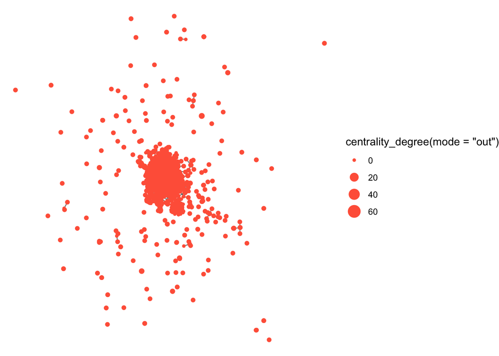

```r
library(ggraph)
library(tidygraph)
g_tbl <- as_tbl_graph(g_2007)

ggraph(g_tbl, layout = "fr") +
  geom_edge_link(alpha = 0.5) +
  geom_node_point(aes(size = centrality_degree(mode = "out")), color="tomato") +
  theme_void()
```

Entraremos en visualizaciones algo más en detalle, pero notamos que podemos usar ahora la gramática de gráficos para los grafos. En este caso quizá querramos no venros ahogados en el mar de rojo tomate no informativo de arriba, y querramos diferenciar los nodos por alguna de las variables, como el país o sector económico al que pertenecen los mismos:

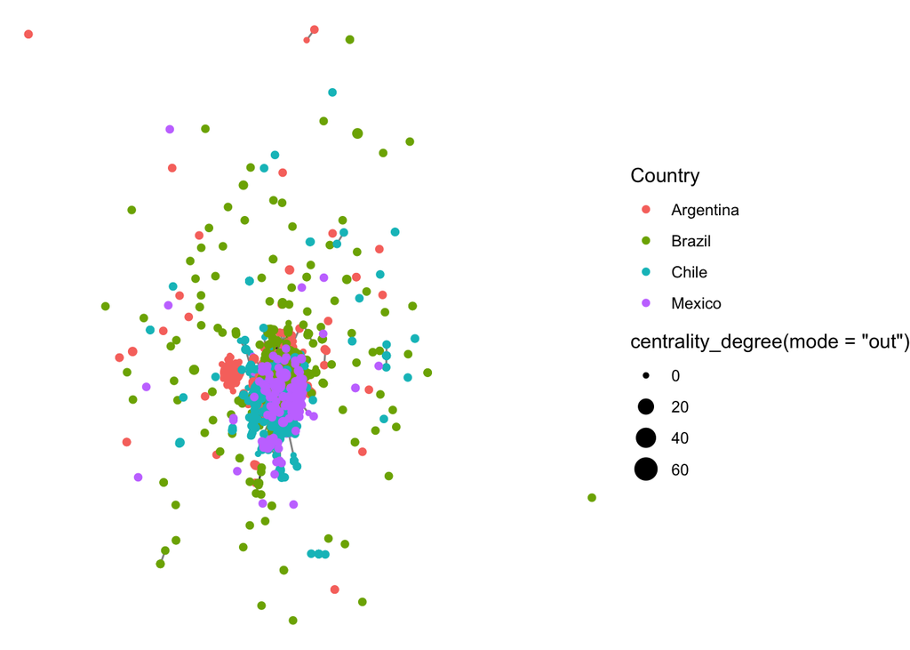

```r
ggraph(g_tbl, layout = "fr") +
  geom_edge_link(alpha = 0.5) +
  geom_node_point(aes(size = centrality_degree(mode = "out"), color = Country)) +
  theme_void()
```

## 2.3 Conceptos estadísticos descriptivos en análisis de redes.

Brevemente iré sobre algunas de las estadísticas descriptivas que se usan frecuentemente en análisis de redes. Si tienen tiempo recomiendo examinar fuentes (esta lista no es exhaustiva) como:

- [A First Course in Network Science](https://cambridgeuniversitypress.github.io/FirstCourseNetworkScience/)
- [Networks (Second Edition)](https://global.oup.com/academic/product/networks-9780198805090?cc=us&lang=en&), y
- [Networks, Crowds, and Markets: Reasoning About a Highly Connected World](https://www.cs.cornell.edu/home/kleinber/networks-book/).

Volviendo a las descriptivas básicas, estas son:

- **Grado**: el número de conexiones que tiene un nodo. En redes dirigidas, se puede hablar de grado de entrada y de salida. En redes ponderadas, se puede hablar de grado ponderado. Se define matemáticamente como $k_i = \sum_{j=1}^{n} a_{ij}$, donde $a_{ij}$ es el elemento de la matriz de adyacencia que indica si hay una conexión entre los nodos $i$ y $j$. En el caso de redes dirigidas, se puede hablar de grado de entrada y de salida, y se define como $k_{i}^{in} = \sum_{j=1}^{n} a_{ji}$ y $k_{i}^{out} = \sum_{j=1}^{n} a_{ij}$, respectivamente, y se le llama también fuerza o grado ponderado.
- **Centralidad**: la centralidad de un nodo mide su importancia en la red. Hay varios tipos de centralidad, como la centralidad de grado, la centralidad de cercanía, la centralidad de intermediación, la centralidad de vector propio, entre otras.
  - La centralidad de grado (*degree*) es simplemente el grado del nodo. Esto es, un nodo es más central si tiene más conexiones. Piensen en una red de amigos: si una persona tiene muchos amigos, es más central en grado que una persona que tiene pocos amigos.
  - La centralidad de cercanía (*closeness*) mide la distancia promedio de un nodo a todos los demás nodos. Un nodo es más central si está más cerca de los demás nodos. Siguiendo con el ejemplo de la red de amigos, una persona que está a una distancia promedio de 2 de todos los demás nodos es más central en cercanía que una persona que está a una distancia promedio de 5.
  - La centralidad de intermediación (*betweenness*) mide cuánto un nodo se encuentra entre los demás nodos. Un nodo es más central si está en el camino más corto entre otros nodos. En la red de amigos, una persona que está en el camino más corto entre todos los demás nodos es más central en intermediación que una persona que no está en el camino más corto entre los demás nodos. Es un puente entre los demás nodos.
  - La centralidad de vector propio (*eigenvector*) mide la importancia de un nodo en función de la importancia de sus vecinos. Un nodo es más central si sus vecinos son más centrales. En la red de amigos, una persona es más central en vector propio si sus amigos son más centrales que los amigos de otra persona.
- **Densidad**: la densidad de una red mide cuántas conexiones hay en la red en relación con todas las posibles conexiones. Se define matemáticamente como $D = \frac{2m}{n(n-1)}$, donde $m$ es el número de conexiones y $n$ es el número de nodos. La densidad de una red varía entre 0 y 1, donde 0 indica que no hay conexiones y 1 indica que todas las posibles conexiones están presentes.
- **Modularidad**: la modularidad de una red mide cuánto la red se divide en comunidades. Una red es modular si se divide en comunidades bien definidas. La modularidad se define matemáticamente como $Q = \frac{1}{2m} \sum_{i,j} (a_{ij} - \frac{k_i k_j}{2m}) \delta(c_i, c_j)$, donde
  - $m$ es el número de conexiones,
  - $a_{ij}$ es el elemento de la matriz de adyacencia que indica si hay una conexión entre los nodos $i$ y $j$,
  - $k_i$ y $k_j$ son los grados de los nodos $i$ y $j$, respectivamente,
  - y $\delta(c_i, c_j)$ es 1 si los nodos $i$ y $j$ están en la misma comunidad y 0 en caso contrario.
  - La modularidad varía entre -1 y 1, donde 1 indica que la red es completamente modular y -1 indica que la red no es modular. En la práctica los valores negativos indican una partición peor que una asignación aleatoria de comunidades y, en muchos contextos, se observa que las modularidades positivas (entre 0 y 1) son las que se interpretan como indicativas de una estructura comunitaria.
- **Coeficiente de clustering**: Mide la proporción de conexiones existentes entre los vecinos de un nodo respecto al número total de conexiones posibles entre ellos. Se define matemáticamente como $C_i = \frac{2t_i}{k_i(k_i - 1)}$, donde $t_i$ es el número de triángulos en los que participa el nodo $i$ (es decir, el número de pares de vecinos de $i$ que están conectados entre sí) y $k_i$ es el grado del nodo $i$ (número de sus vecinos). Este coeficiente varía entre 0 y 1:
  - Un valor de 0 indica que ninguno de los vecinos está conectado con otro,
  - Un valor de 1 indica que todos los vecinos están completamente interconectados, formando así un clúster cerrado.
- **Longitud del camino más corto**: la longitud del camino más corto entre dos nodos refiere a la mínima cantidad de pasos (o aristas) que se deben recorrer para conectar dos nodos en una red. Matemáticamente, se define como $d_{ij} = \min_{p_{ij}} \sum_{(u,v) \in p_{ij}} 1$,donde $p_{ij}$ representa cada camino posible entre los nodos $i$ y $j$ y la suma recorre todas las aristas $(u,v)$ del camino. Cada arista contribuye con un valor de $1$, por lo que la suma total es el número de pasos necesarios para conectar $i$ y $j$. La longitud del camino más corto varía entre 1 (cuando $i$ y $j$ están directamente conectados) e $\infty$ (cuando no existe ningún camino que los conecte).
- **Transitividad**: la transitividad de una red mide cuántos triángulos hay en la red en relación con todas las tripletes conectadas (es decir $\Delta/\Lambda$). Se define matemáticamente como $T = \frac{3 \times \text{número de triángulos}}{\text{número de tripletes conectados}}$. La transitividad de una red varía entre 0 y 1, donde 0 indica que no hay triángulos y 1 indica que todos los posibles triángulos están presentes. También se le refiere como coeficiente de clustering global o cierre triádico.

## 2.4 Midiendo conceptos estadísticos en R

Estos conceptos anteriormente mencionados se pueden medir en R con las siguientes funciones:

### 2.4.1 Densidad

```r
#Densidad del grafo g_2007
densidad<- igraph::edge_density(g_2007)
densidad
```

```
## [1] 0.001496587
```

Vemos una densidad de 0.0015, lo que indica que la red es muy poco densa. Recordemos que densidad puede ser en mínimo 0, es decir, de todos los nodos, ninguno está conectado, y en máximo 1, es decir, todos los nodos están conectados, y han alcanzado el máximo de conexiones posibles. Es improbable ver redes de densidad 1, pero sí muchas *cercanas* a densidad 0 absoluto.

### 2.4.2 Modularidad

```r
#Modularidad del grafo g_2007
comunidades <- cluster_infomap(g_2007)
modularidad <- igraph::modularity(g_2007, comunidades$membership)
modularidad
```

```
## [1] 0.3644385
```

La modularidad del grafo es de 0.36, lo que indica que la red tiene una estructura de comunidades. En la sección de visualización veremos cómo se ven las mismas.

### 2.4.3 Grado ponderado

```r
#Grado ponderado del grafo g_2007
grado_ponderado <- igraph::strength(g_2007, mode = "out", loops = FALSE)
grado_ponderado
```

```
##    1    2    3    4    5    6    7    8    9   10   11   12   13   14   15   16
##    0    0    0    0    1    0    1    1    0    1    0    0    0    0    0    0
##   17   18   19   20   21   22   23   24   25   26   27   28   29   30   31   32
##    0    0    0    0    0    0    0    0    0    0    0    0    0    0    0    0
##   33   34   35   36   37   38   39   40   41   42   43   44   45   46   47   48
##    0    0    0    0    0    0    0    0    0    0    0    0    0    0    0    0
##   49   50   51   52   53   54   55   56   57   58   59   60   61   62   63   64
##    0    0    0    0    0    0    0    0    0    0    0    0    0    0    0    0
##   65   66   67   68   69   70   71   72   73   74   75   76   77   78   79   80
##    0    0    0    0    0    0    0    0    0    0    0    0    0    0    0    0
##   81   82   83   84   85   86   87   88   89   90   91   92   93   94   95   96
##    0    0    0    0    0    0    0    0    0    0    0    0    0    0    0    0
##   97   98   99  100  101  102  103  104  105  106  107  108  109  110  111  112
##    0    0    0    0    0    0    0    0    0    0    0    0    0    0    0    0
##  113  114  115  116  117  118  119  120  121  122  123  124  125  126  127  128
```

[output cut: 179 more lines]

```r
summary(grado_ponderado)
```

```
##    Min. 1st Qu.  Median    Mean 3rd Qu.    Max.
##   0.000   0.000   1.000   2.303   1.000  78.000
```

Vemos las salidas tanto de grados de cada nodo como un resumen de los grados ponderados. El promedio es de 2.3, lo que indica que la red tiene nodos con grados muy bajos (0) y otros con grados muy altos (78). Si un nodo tiene unos dos grados, esto significa que tiene dos conexiones con otros nodos.

### 2.4.4 Centralidades

#### 2.4.4.1 Centralidad de grado

```r
centralidad_grado <- degree(g)
centralidad_grado
```

```
##    [1]  0  0  0  0  0  0  0  0  0  0  0  0  0  0  0  0  0  0  0  0  0  0  0  0
##   [25]  0  0  0  0  0  0  0  0  0  0  0  0  0  0  0  0  0  0  0  0  0  0  0  0
##   [49]  0  0  0  0  0  0  0  0  0  0  0  0  0  0  0  0  0  0  0  0  0  0  0  0
##   [73]  0  0  0  0  0  0  0  0  0  0  0  0  0  0  0  0  0  0  0  0  0  0  0  0
##   [97]  0  0  0  0  0  0  0  0  0  0  0  0  0  0  0  0  0  0  0  0  0  0  0  0
##  [121]  0  0  0  0  0  0  0  0  0  0  0  0  0  0  0  0  0  0  0  0  0  0  0  0
##  [145]  0  0  0  0  0  0  0  0  0  0  0  0  0  0  0  0  0  0  0  0  0  0  0  0
##  [169]  0  0  0  0  0  0  0  0  0  0  0  0  0  0  0  0  0  0  0  0  0  0  0  0
##  [193]  0  0  0  0  0  0  0  0  0  0  0  0  0  0  0  0  0  0  0  0  0  0  0  0
##  [217]  0  0  0  0  0  0  0  0  0  0  0  0  0  0  0  0  0  0  0  0  0  0  0  0
##  [241]  0  0  0  0  0  0  0  0  0  0  0  0  0  0  0  0  0  0  0  0  0  0  0  0
##  [265]  0  0  0  0  0  0  0  0  0  0  0  0  0  0  0  0  0  0  0  0  0  0  0  0
##  [289]  0  0  0  0  0  0  0  0  0  0  0  0  0  0  0  0  0  0  0  0  0  0  0  0
##  [313]  0  0  0  0  0  0  0  0  0  0  0  0  0  0  0  0  0  0  0  0  0  0  0  0
##  [337]  0  0  0  0  0  0  0  0  0  0  0  0  0  0  0  0  0  0  0  0  0  0  0  0
```

[output cut: 30 more lines]

#### 2.4.4.2 Centralidad de cercanía

```r
centralidad_cercania <- closeness(g)
summary(centralidad_cercania)
```

```
##    Min. 1st Qu.  Median    Mean 3rd Qu.    Max.    NA's
##  0.0169  0.0244  0.0294  0.0298  0.0357  0.0435    1053
```

#### 2.4.4.3 Centralidad de intermediación

```r
centralidad_intermediacion <- betweenness(g)
summary(centralidad_intermediacion)
```

```
##     Min.  1st Qu.   Median     Mean  3rd Qu.     Max.
##   0.0000   0.0000   0.0000   0.5019   0.0000 128.2556
```

#### 2.4.4.4 Centralidad de vector propio

```r
centralidad_vector_propio <- eigen_centrality(g)$vector
summary(centralidad_vector_propio)
```

```
##     Min.  1st Qu.   Median     Mean  3rd Qu.     Max.
## 0.000000 0.000000 0.000000 0.009132 0.000000 1.000000
```

En promedio la centralidad de vector propio es de aproximadamente 0.01. Esto indica que en general, la mayoría de los nodos no están especialmente «empoderados» a través de sus conexiones. Es decir, no existe un grupo muy destacado de nodos con vecinos altamente centrales (o, si existe, su efecto queda muy diluido en el conjunto de la red). En redes grandes, un valor promedio bajo de centralidad de vector propio indica que la influencia relativa de los nodos (considerando la importancia de sus vecinos) se distribuye de forma bastante homogénea o con pocos picos de gran relevancia.

### 2.4.5 Coeficiente de clustering

```r
#Coeficiente de clustering del grafo g_2007
coef_clustering_local <- transitivity(g, type = "local")
coef_clustering_global <- transitivity(g, type = "global")
summary(coef_clustering_local)
```

```
##    Min. 1st Qu.  Median    Mean 3rd Qu.    Max.    NA's
##  0.0000  0.3333  0.5000  0.5389  0.6667  1.0000    1053
```

```r
coef_clustering_global
```

```
## [1] 0.4732394
```

El coeficiente de clustering local se calcula para cada nodo $i$ como la fracción de conexiones que existen entre sus vecinos, en relación con las conexiones posibles. Mientras que el coeficiente de clustering global se basa en la proporción de tripletes cerrados (triángulos) en toda la red con respecto al total de tripletes conectados, no en el promedio del mismo (como hice en el caso local). Las diferencias pueden ser sutiles, pero importantes, pues en estos casos podrían indicarme que hay una distribución desigual de conexiones en la red: unos vecinos muy bien conectados, otros no tanto. O puede haber muchos nodos con bajo clustering local que, sin embargo, al sumarse, arrojan un valor global diferente al promedio de los locales.

Estas estadísticas descriptivas nos dan una idea de cómo está estructurada la red, de los tipos de conexiones que hay en ella a nivel global. También podemos usarla para identificar estadísticas relacionadas al nodo a nivel individual. Dependiendo el nivel de análisis que estemos llevando a cabo, convendrá usar una u otra, o ambas.

Por ejemplo, en mi caso usé estas y otras estadísticas agregadas del grafo para luego hacer análisis comparado macroeconómico combinado a otras estadísticas más estándares en socioeconomía y política y evaluar así cómo la estructura de redes en agregado se relacionaba con conceptos de capitalismo comparado. Por otro lado, si lo que quisiéramos es entender qué actor es crucial para conectar pedazos de la red, garantizar el flujo de información, o entender cómo se distribuye la influencia en una red, las estadísticas a nivel del nodo nos pueden ayudar a entenderlo.

## 2.5 ERGMs

Los Modelos Exponenciales de Grafos Aleatorios (ERGM) permiten modelar la probabilidad de que se forme una red observada en función de las características de los nodos, las aristas y las estructuras de red. Se usan para analizar redes sociales, económicas y políticas, proporcionando una forma estadística de inferir mecanismos estructurales de formación de redes.

```r
library(igraph)
library(tidygraph)
library(network)
library(ergm)
library(intergraph)
net_2007 <- asNetwork(g_2007)  # Convierte el grafo de igraph a network
summary(net_2007, print.adj = FALSE)  # Muestra información sobre la red, quité la opción de mostrar la lista entera de adyacencia ya que era absurdamente larga.
```

```
## Network attributes:
##   vertices = 1540
##   directed = TRUE
##   hyper = FALSE
##   loops = FALSE
##   multiple = FALSE
##   bipartite = FALSE
##  total edges = 3547
##    missing edges = 0
##    non-missing edges = 3547
##  density = 0.001496587
##
## Vertex attributes:
##
##  CompanyPerson:
##    character valued attribute
##    attribute summary:
##    the 10 most common values are:
##                                      [datatruncated]
##                                                    1
##  521 participacoes s/a - em liquidacao extrajudicial
##                                                    1
## a.f.p. cuprum s.a. para el fondo de pensiones tipo c
##                                                    1
##                                  a.f.p. habitat s.a.
##                                                    1
##                                        ab electrolux
##                                                    1
##                        aberdeen asset management plc
##                                                    1
##                         abertis infraestructuras, sa
##                                                    1
##              abn amro brasil dois participacoes s.a.
##                                                    1
##                                 accel s.a.b. de c.v.
##                                                    1
##           accionistas agrupados (bolsas del exterio)
##                                                    1
##
##  CondensedSector:
```

[output cut: 18 more lines]

```
##   vertex.names:
##    character valued attribute
##    1540 valid vertex names
##
##  Year:
##    integer valued attribute
##    1540 values
##
## Edge attributes:
##
##  Weight:
##    numeric valued attribute
##    attribute summary:
##    Min. 1st Qu.  Median    Mean 3rd Qu.    Max.
##   0.010   0.310   0.720   8.766   2.825 100.000
```

Y podemos ajustar un modelo ERGM a la red `net_2007` de dos formas

```r
# Convertir la red en no dirigida
g_2007_undirected <- as_undirected(g_2007, mode = "collapse")

# Convertir a network
library(intergraph)
library(Rglpk)
net_2007_undirected <- asNetwork(g_2007_undirected)

# Ajustar el modelo ERGM
fit_ergm <- ergm(net_2007_undirected ~ edges + triangles)
```

```
## Starting maximum pseudolikelihood estimation (MPLE):
```

```
## Obtaining the responsible dyads.
```

```
## Evaluating the predictor and response matrix.
```

```
## Maximizing the pseudolikelihood.
```

```
## Finished MPLE.
```

```
## Starting Monte Carlo maximum likelihood estimation (MCMLE):
```

```
## Iteration 1 of at most 60:
```

```
## 1 Optimizing with step length 0.2938.
## The log-likelihood improved by 3.8415.
## Estimating equations are not within tolerance region.
## Iteration 2 of at most 60:
## 1 Optimizing with step length 0.8563.
## The log-likelihood improved by 3.6170.
## Estimating equations are not within tolerance region.
## Iteration 3 of at most 60:
## 1 Optimizing with step length 1.0000.
## The log-likelihood improved by 0.3952.
## Estimating equations are not within tolerance region.
## Iteration 4 of at most 60:
## 1 Optimizing with step length 1.0000.
## The log-likelihood improved by 0.0897.
## Convergence test p-value: 0.0350. Not converged with 99% confidence; increasing sample size.
## Iteration 5 of at most 60:
## 1 Optimizing with step length 1.0000.
## The log-likelihood improved by 0.0025.
## Convergence test p-value: 0.0218. Not converged with 99% confidence; increasing sample size.
## Iteration 6 of at most 60:
## 1 Optimizing with step length 1.0000.
## The log-likelihood improved by 0.0163.
## Convergence test p-value: 0.0009. Converged with 99% confidence.
## Finished MCMLE.
## Evaluating log-likelihood at the estimate. Fitting the dyad-independent submodel...
## Bridging between the dyad-independent submodel and the full model...
## Setting up bridge sampling...
## Using 16 bridges: 1 2 3 4 5 6 7 8 9 10 11 12 13 14 15 16 .
## Bridging finished.
##
## This model was fit using MCMC.  To examine model diagnostics and check
## for degeneracy, use the mcmc.diagnostics() function.
```

```r
summary(fit_ergm)
```

```
## Call:
## ergm(formula = net_2007_undirected ~ edges + triangles)
##
## Monte Carlo Maximum Likelihood Results:
##
##          Estimate Std. Error MCMC %  z value Pr(>|z|)
## edges    -5.83452    0.01724      0 -338.481   <1e-04 ***
## triangle  1.06486    0.14804      0    7.193   <1e-04 ***
## ---
## Signif. codes:  0 '***' 0.001 '**' 0.01 '*' 0.05 '.' 0.1 ' ' 1
##
##      Null Deviance: 1642800  on 1185030  degrees of freedom
##  Residual Deviance:   48269  on 1185028  degrees of freedom
##
## AIC: 48273  BIC: 48297  (Smaller is better. MC Std. Err. = 0.9052)
```

Las díadas responsables de las interacciones de los nodos se registrearon y se evaluó la matriz de predictores y respuestas. Se realizó una primera estimación por máxima pseudoverosimilitud (MPLE) y luego se pasó la máxima verosimilitud por iteraciones de Monte Carlo (MCMC) para obtener estimaciones de los parámetros y sus intervalos de confianza. Observamos varios ciclos iterativos hasta que modelo convergiera en bondad de ajuste. Se utilizó un modelo de puentes para refinar la estimación final de verosimilitud y finalizó la estimación, almacenando los datos en un objeto `fit_ergm`. Este se ve a través de la función de resumen, `summary(fit_ergm)`, que nos da una idea de cómo se ajustó el modelo a los datos.

Los parámetros del modelo ERGM se pueden interpretar como los efectos de las variables en la red que vemos conformada. El parámetro base de las aristas (edges) es negativo, pero la presencia de triángulos aumenta la probabilidad de ver otras aristas. El mensaje final recomienda usar `mcmc.diagnostics()` para evaluar la calidad de la cadena de Markov y descartar problemas de degeneración o falta de convergencia.

Este modelo fue sencillo en variables explicativas, pero se pueden añadir más variables. En este caso, lo haré pero con una instrucción adicional para, por cuestiones de tiempo, se quede en la pseudo-verosimilitud máxima.

```r
fit_ergm <- ergm(net_2007 ~ edges + triangles + gwesp(0.5)+gwdsp(0.5) + nodefactor("CondensedSector")+nodecov("Revenue"),
                 estimate = "MPLE")
```

```
## Starting maximum pseudolikelihood estimation (MPLE):
```

```
## Obtaining the responsible dyads.
```

```
## Evaluating the predictor and response matrix.
```

```
## Maximizing the pseudolikelihood.
```

```
## Finished MPLE.
```

```
## Evaluating log-likelihood at the estimate.
```

```r
summary(fit_ergm)
```

```
## Call:
## ergm(formula = net_2007 ~ edges + triangles + gwesp(0.5) + gwdsp(0.5) +
##     nodefactor("CondensedSector") + nodecov("Revenue"), estimate = "MPLE")
##
## Maximum Pseudolikelihood Results:
##
##                                                   Estimate Std. Error MCMC %
## edges                                           -1.938e+00  5.143e-02      0
## triangle                                        -1.893e-03  9.338e-01      0
## gwesp.OTP                                       -1.890e-03  9.371e-01      0
## gwesp.OTP.decay                                  1.040e-19  5.606e+02      0
## gwdsp.OTP                                       -6.381e-01  9.740e-03      0
## gwdsp.OTP.decay                                  4.027e-05  2.383e-01      0
## nodefactor.CondensedSector.Bank                 -4.616e-01  3.063e-02      0
## nodefactor.CondensedSector.Financial sector     -1.115e+00  2.824e-02      0
## nodefactor.CondensedSector.Individuals/Families -5.043e-01  3.044e-02      0
## nodefactor.CondensedSector.Nonfinancial sector  -1.496e+00  2.738e-02      0
## nodefactor.CondensedSector.Public or Government -1.412e-01  3.846e-02      0
## nodefactor.CondensedSector.Selfowned            -7.139e-03  1.251e-01      0
## nodecov.Revenue                                  7.797e-09  1.607e-09      0
##                                                 z value Pr(>|z|)
## edges                                           -37.685  < 1e-04 ***
## triangle                                         -0.002  0.99838
## gwesp.OTP                                        -0.002  0.99839
## gwesp.OTP.decay                                   0.000  1.00000
## gwdsp.OTP                                       -65.515  < 1e-04 ***
## gwdsp.OTP.decay                                   0.000  0.99987
## nodefactor.CondensedSector.Bank                 -15.069  < 1e-04 ***
## nodefactor.CondensedSector.Financial sector     -39.489  < 1e-04 ***
## nodefactor.CondensedSector.Individuals/Families -16.568  < 1e-04 ***
## nodefactor.CondensedSector.Nonfinancial sector  -54.660  < 1e-04 ***
## nodefactor.CondensedSector.Public or Government  -3.672  0.00024 ***
## nodefactor.CondensedSector.Selfowned             -0.057  0.95450
## nodecov.Revenue                                   4.851  < 1e-04 ***
## ---
## Signif. codes:  0 '***' 0.001 '**' 0.01 '*' 0.05 '.' 0.1 ' ' 1
##
## Warning:  The standard errors are based on naive pseudolikelihood and are suspect. Set control.ergm$MPLE.covariance.method='Godambe' for a simulation-based approximation of the standard errors.
##
##      Null Pseudo-deviance: 3285601  on 2370060  degrees of freedom
##  Residual Pseudo-deviance:   64834  on 2370047  degrees of freedom
##
## AIC: 64860  BIC: 65025  (Smaller is better. MC Std. Err. = 0)
```

El coeficiente de edges es la base, y aquí es como hablar del intercepto. En ausencia de otros efectos, la tendencia base es que no se formen conexiones, o que hay un costo base para formar vínculos. El coeficiente de triángulos ahora es casi cero y no significativo, lo que indica que la presencia de triángulos no afecta la probabilidad de formar otras aristas. GWESP se traduce como “compartidos ponderados generalizados por arista” y GWDSP como «compartidos ponderados generalizados por díada». Estos términos se añaden a los modelos ERGM con frecuencia para ayudar a estabilizarlos y evitar problemas de degeneración, ya que capturan estructuras de conectividad más complejas en la red que los términos básicos (como triángulos o aristas), aportando información adicional sobre cómo los nodos comparten vecinos o díadas. Esto permite que el modelo ajuste de manera más precisa las dependencias locales en la red. Si bien GWESP resultó no ser significativo, GWDSP lo es (aunque la función de decaída no lo es). Indica que cuando existen díadas con vecinos compartidos, esta estructura tiende a reducir la probabilidad de formar nuevas conexiones. Es como decir que, tras cierto nivel de “redundancia” en la red, se vuelve menos probable que se generen nuevos vínculos. Los coeficientes asociados a las distintas categorías del sector (por ejemplo, `Bank`, `Financial sector`, `Individuals/Families`, `Nonfinancial sector`, `Public or Government`) son todos negativos y muy significativos, lo que indica que, comparados con la categoría de referencia, estos sectores tienen una menor propensión a formar conexiones en este sistema económico. En términos de un modelo econométrico, es como si ciertos grupos o sectores presentaran barreras o costos adicionales para generar interacciones. La categoría `Selfowned` no muestra un efecto significativo. Finalmente, el coeficiente de `Revenue` es positivo y significativo, lo que indica que, a mayor ingreso, la probabilidad de formar conexiones es mayor. En términos económicos, esto podría interpretarse como que las entidades con mayores ingresos tienen una mayor capacidad para establecer relaciones con otros actores en la red.

Si hiciéramos el análisis con la red de estudiantes de más temprano, podríamos rápidamente ahora ver:

```r
# Dropear los naas de classroom
# Identificar los nodos que no tienen NA en "isei08_m"
nodos_validos <- which(!is.na(V(classroom)$isei08_m))

# Crear un subgrafo que contenga solo esos nodos
classroom_clean <- induced_subgraph(classroom, vids = nodos_validos)
# Elimina esos nodos de la red
classroom_net <- asNetwork(classroom_clean)

# Resumir la red sin imprimir toda la lista de aristas
summary(classroom_net, print.adj = FALSE)
```

```
## Network attributes:
##   vertices = 21
##   directed = TRUE
##   hyper = FALSE
##   loops = FALSE
##   multiple = FALSE
##   bipartite = FALSE
##  total edges = 60
##    missing edges = 0
##    non-missing edges = 60
##  density = 0.1428571
##
## Vertex attributes:
##
##  female:
##    logical valued attribute
##    attribute summary:
##    Mode   FALSE    TRUE
## logical       9      12
##
##  isei08_f:
##    numeric valued attribute
##    attribute summary:
##    Min. 1st Qu.  Median    Mean 3rd Qu.    Max.    NA's
##   11.74   25.04   25.71   28.76   29.83   51.50       1
##
##  isei08_m:
##    numeric valued attribute
##    attribute summary:
##    Min. 1st Qu.  Median    Mean 3rd Qu.    Max.
##   14.21   23.47   26.64   31.88   28.48   76.49
##   vertex.names:
##    character valued attribute
##    21 valid vertex names
##
## Edge attributes:
##
##  liking:
##    integer valued attribute
##    60values
```

```r
fit_ergm_classroom <- ergm(classroom_net ~ edges + triangles + gwesp()+gwdsp()+
                             nodefactor("female") + nodecov("isei08_m"),
                           estimate = "MPLE")
```

```
## Starting maximum pseudolikelihood estimation (MPLE):
```

```
## Obtaining the responsible dyads.
```

```
## Evaluating the predictor and response matrix.
```

```
## Maximizing the pseudolikelihood.
```

```
## Finished MPLE.
```

```
## Evaluating log-likelihood at the estimate.
```

```r
# Mostrar el resumen del modelo
summary(fit_ergm_classroom)
```

```
## Call:
## ergm(formula = classroom_net ~ edges + triangles + gwesp() +
##     gwdsp() + nodefactor("female") + nodecov("isei08_m"), estimate = "MPLE")
##
## Maximum Pseudolikelihood Results:
##
##                          Estimate Std. Error MCMC % z value Pr(>|z|)
## edges                  -9.743e-01  7.090e-01      0  -1.374  0.16938
## triangle                3.656e-01  1.182e-01      0   3.093  0.00198 **
## gwesp.OTP               3.871e-01  2.336e-01      0   1.657  0.09746 .
## gwesp.OTP.decay         4.312e-11  6.422e-01      0   0.000  1.00000
## gwdsp.OTP              -1.970e-01  8.890e-02      0  -2.216  0.02666 *
## gwdsp.OTP.decay         1.463e-03  7.886e-01      0   0.002  0.99852
## nodefactor.female.TRUE -1.386e-01  2.122e-01      0  -0.653  0.51348
## nodecov.isei08_m       -1.851e-02  8.454e-03      0  -2.190  0.02854 *
## ---
## Signif. codes:  0 '***' 0.001 '**' 0.01 '*' 0.05 '.' 0.1 ' ' 1
##
## Warning:  The standard errors are based on naive pseudolikelihood and are suspect. Set control.ergm$MPLE.covariance.method='Godambe' for a simulation-based approximation of the standard errors.
##
##      Null Pseudo-deviance: 582.2  on 420  degrees of freedom
##  Residual Pseudo-deviance: 227.9  on 412  degrees of freedom
##
## AIC: 243.9  BIC: 276.2  (Smaller is better. MC Std. Err. = 0)
```

El coeficiente de aristas no es significativo, lo que indica que la tendencia base a formar vínculos no difiere significativamente de cero. El de triángulos sí es positivo y significativo, que indica una fuerte tendencia al cierre triádico. Los términos de GWESP y su decaída son positivos. Esto muestra una tendencia marginal a que los vecinos compartidos en una conexión influyan en la formación de vínculos, aunque su significancia es apenas marginal $(p ≈ 0.097)$. GWDSP es negativo y significativo, una mayor cantidad de díadas con vecinos compartidos reduce la probabilidad de formar nuevos vínculos. El efecto del género no es significativo, lo que indica que no hay diferencias relevantes en la formación de vínculos según el género. El coeficiente negativo y significativo de la covariable `isei08_m` sugiere que, a mayor estatus socioeconómico (o capital social) del padre, menor es la probabilidad de que el niño establezca vínculos. En términos económicos, esto podría interpretarse como que los niños de familias con mayor capital social tienen menos necesidad de establecer o reportar relaciones en la red.

# 3 Importando datos de ejemplo 3

Moviéndonos a la visualización, cargaré unos datos que estoy editando para un artículo a publicar más tarde en la primavera de 2025. Estos datos son de una red de élites económicas ecuatorianas. Les muestro en el salón la versión original en Excel, y ahora el cargado:

```r
load("grafo_sin_aislados.RData")
library(tidygraph)
library(tidyverse)
library(scales)
```

El paquete `tidygraph` utiliza `igraph` internamente para almacenar datos de redes, pero proporciona una interfaz “ordenada” para la manipulación de datos. Los datos de la red se gestionan como dos marcos de datos interconectados: (1) nodos y (2) aristas. Esto es muy similar a la estructura de datos aceptada por la función `igraph::graph_from_data_frame()`, como se demostró anteriormente.

A modo de ejemplo con el caso de los datos de niños en salones de clase:

```r
tg_classroom <- tbl_graph(nodes = classroom_kids, edges = classroom_play,
                          directed = TRUE)
tg_classroom
```

```
## # A tbl_graph: 26 nodes and 88 edges
## #
## # A directed simple graph with 2 components
## #
## # Node Data: 26 × 4 (active)
##    name  female isei08_m isei08_f
##    <chr> <lgl>     <dbl>    <dbl>
##  1 1003  FALSE      NA       25.7
##  2 1006  TRUE       14.6     33.8
##  3 1009  TRUE       28.5     37.2
##  4 1012  TRUE       26.6     25.2
##  5 1015  TRUE       21.2     NA
##  6 1018  FALSE      23.5     24.4
##  7 1021  TRUE       21.2     25.2
##  8 1024  FALSE      NA       25.7
##  9 1027  TRUE       NA       26.0
## 10 1030  TRUE       26.6     25.7
## # ℹ 16 more rows
## #
## # Edge Data: 88 × 3
##    from    to liking
##   <int> <int>  <int>
## 1     1     6      3
## 2     1    17      3
## 3     1    24      4
## # ℹ 85 more rows
```

y `as_tbl_graph()` convierte un grafo de `igraph` en un objeto de `tidygraph`.

```r
tg_classroom2 <- as_tbl_graph(classroom)
tg_classroom2
```

```
## # A tbl_graph: 26 nodes and 88 edges
## #
## # A directed simple graph with 2 components
## #
## # Node Data: 26 × 4 (active)
##    name  female isei08_m isei08_f
##    <chr> <lgl>     <dbl>    <dbl>
##  1 1003  FALSE      NA       25.7
##  2 1006  TRUE       14.6     33.8
##  3 1009  TRUE       28.5     37.2
##  4 1012  TRUE       26.6     25.2
##  5 1015  TRUE       21.2     NA
##  6 1018  FALSE      23.5     24.4
##  7 1021  TRUE       21.2     25.2
##  8 1024  FALSE      NA       25.7
##  9 1027  TRUE       NA       26.0
## 10 1030  TRUE       26.6     25.7
## # ℹ 16 more rows
## #
## # Edge Data: 88 × 3
##    from    to liking
##   <int> <int>  <int>
## 1     1     6      3
## 2     1    17      3
## 3     1    24      4
## # ℹ 85 more rows
```

Con ello se puede trabajar los atributos de una manera más intuitiva o al menos basada en un lenguaje al que ya estamos familiarizados:

```r
tg_classroom |>
  activate(nodes) |>
  mutate(
    status = pmin(isei08_m, isei08_f, na.rm=TRUE)
  )
```

```
## # A tbl_graph: 26 nodes and 88 edges
## #
## # A directed simple graph with 2 components
## #
## # Node Data: 26 × 5 (active)
##    name  female isei08_m isei08_f status
##    <chr> <lgl>     <dbl>    <dbl>  <dbl>
##  1 1003  FALSE      NA       25.7   25.7
##  2 1006  TRUE       14.6     33.8   14.6
##  3 1009  TRUE       28.5     37.2   28.5
##  4 1012  TRUE       26.6     25.2   25.2
##  5 1015  TRUE       21.2     NA     21.2
##  6 1018  FALSE      23.5     24.4   23.5
##  7 1021  TRUE       21.2     25.2   21.2
##  8 1024  FALSE      NA       25.7   25.7
##  9 1027  TRUE       NA       26.0   26.0
## 10 1030  TRUE       26.6     25.7   25.7
## # ℹ 16 more rows
## #
## # Edge Data: 88 × 3
##    from    to liking
##   <int> <int>  <int>
## 1     1     6      3
## 2     1    17      3
## 3     1    24      4
## # ℹ 85 more rows
```

## 3.1 Representación visual de redes

Podríamos visualizar entonces este ejemplo

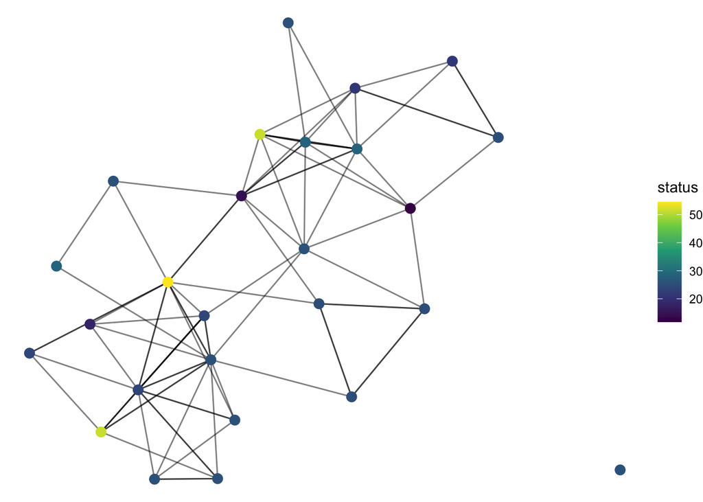

```r
tg_classroom_mod <- tg_classroom |>
  activate(nodes) |>
  mutate(status = pmin(isei08_m, isei08_f, na.rm = TRUE))

ggraph(tg_classroom_mod, layout = "kk") + # Algoritmo de Kamada-Kawai
  geom_edge_link(alpha = 0.5) +
  geom_node_point(aes(color = status), size = 3) +
  scale_color_viridis_c() +
  theme_void()
```

Usando los datos cargados para el ejemplo dos, digamos que queremos visualizar las comunidades que identificamos al hacer los análisis en modularidad previos.

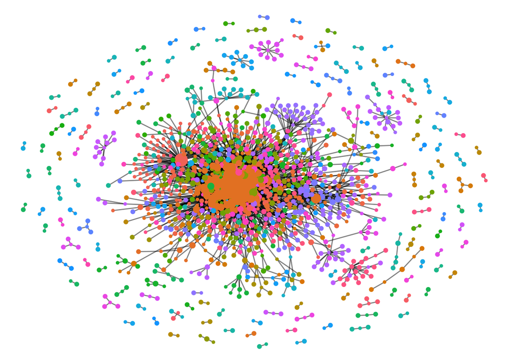

```r
# Ya tenemos 'comunidades' sacado con cluster_infomap:
# Añadimos la membresía como atributo a cada nodo
g_tbl <- as_tbl_graph(g_2007) %>%
  mutate(comunidad = factor(comunidades$membership))

# Visualizamos el grafo, coloreando los nodos según la comunidad
ggraph(g_tbl, layout = "graphopt") + # Similar a Fruchterman-Reingold
  geom_edge_link(alpha = 0.5) +
  geom_node_point(aes(color = comunidad, size = centrality_degree(mode = "out"))) +
  theme_void() +
  theme(legend.position = "none") # apagué en este caso la leyenda ya que habían cientos de pequeñas comunidades identificadas.
```

Volviendo al caso de ejemplo de las élites ecuatorianas, se puede hacer lo siguiente, sabiendo que están distribuidas a través de regiones y épocas varias.

```r
# Convertir el grafo de igraph a tidygraph para usar ggraph
grafo_tidy <- as_tbl_graph(grafo_sin_aislados) |>
  activate(nodes) |>
  mutate(
    familia_core = if_else(familia_core == "no", "non-original-caste", familia_core),
    color = case_when(
      familia_core == "Firm" ~ "gold",
      familia_core == "Fortunas" ~ "red",
      familia_core == "Guayaquil" ~ "cyan",
      TRUE ~ "blue"
    ),
    sizevar = case_when(
      familia_core == "Firm" ~ 2,
      familia_core == "Fortunas" ~ 5,
      familia_core == "Guayaquil" ~ 4,
      TRUE ~ 1
    ),
    size_degree = rescale(centrality_degree(), to = c(3, 10)),
    size_combined = sizevar + size_degree
  ) |>
  activate(edges) |>
  mutate(
    #cambiar el nombre de república velasquista a república tardía
    periodocat = case_when(
      periodocat == "república_velasquista" ~ "república_tardía",
      TRUE ~ periodocat
    ),
    periodocat = factor(
      periodocat,
      levels = c("colonial", "república_temprana", "república_media", "república_tardía")
    )
  )
```

En la parte anterior se hizo una serie de modificaciones al grafo original para fines de crear la estética deseada. Se le añadió un color y tamaño a los nodos, y se le añadió un tamaño adicional a los nodos en función de su grado. Se le añadió un factor a los periodos históricos para que se ordenaran de manera correcta en la visualización, es decir, ya que no intuiría adecuadamente las categorías, les di un orden de eras o periodos históricos.

Podemos pasar a ejecutar la visualización con `ggplot2` y `ggraph`.

- `geom_edge_link()` dibuja las aristas con colores y estilos según `tietype` y `periodocat`.
- `geom_node_point()` asigna colores y tamaños a los nodos.
- Se usa `scale_color_manual()` para definir los colores de las categorías.
- Se aplica `theme_graph()` para mejorar la estética y se añade un título.

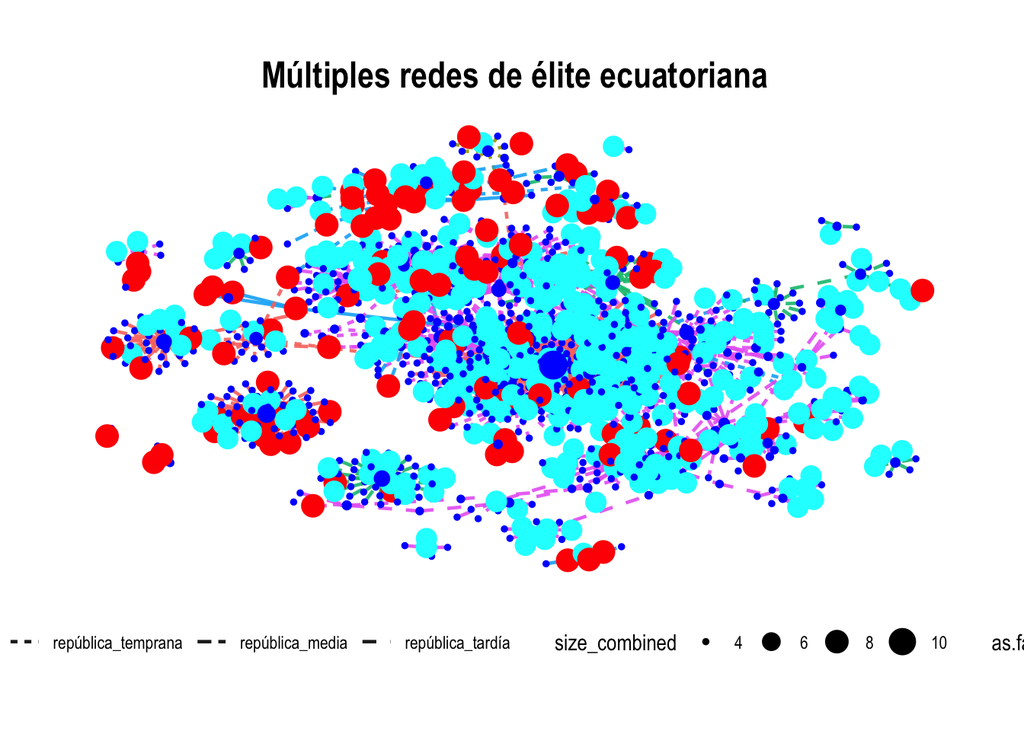

```r
# Visualizar el grafo con ggraph
ggraph(grafo_tidy, layout = "graphopt") +
  geom_edge_link(
    aes(color = as.factor(tietype), linetype = periodocat),
    alpha = 0.9,
    width = 0.8
  ) +
  geom_node_point(aes(color = color, size = size_combined)) +
  scale_color_manual(
    values = c("red" = "red", "blue" = "blue", "gold" = "gold", "cyan" = "cyan"),
    name = "Hierarchical status",
    labels = c("Fortunas", "Guayaquil", "Entidades", "Casta")
  ) +
  theme_graph() +
  ggtitle("Múltiples redes de élite ecuatoriana") +
  theme(
    legend.position = "bottom",
    plot.title = element_text(hjust = 0.5)
  )
```

Podemos ver entonces las relaciones representadas en la gran complejidad de la red de élites a través del tiempo con esta visualización. Las fortunas o élites originarias, las familias de Guayaquil, las entidades y las castas se ven en colores distintos, y las relaciones entre ellas se ven en los vínculos, coloreados por la subred y con rayas de distinto tipo para marcar la era en la que se da el vínculo. Los nodos más grandes son los que tienen más conexiones. Este grafo es realmente la combinación de cuatro grafos de eras distintas, y se ve la complejidad de las relaciones entre las élites a lo largo del tiempo. (Recomiendo vean la imagen en el correo para ver con mayor resolución la red).

# 4 Qué aprendimos en este taller

Aprendimos la existencia de varios acercamientos de R para trabajar con redes, desde lo descriptivo, inferencial y de visualizaciones. Con esto concluimos esta serie de talleres sobre R, y espero que les haya sido de utilidad. Si tienen alguna pregunta, no duden en contactarme a mi correo electrónico. ¡Gracias por su atención!